# Tree

Tree merupakan struktur data yang berbentuk non linear, berbeda dengan struktur data stack, queue, ataupun deque. Bentuk Tree di computer science hampir sama dengan tree yang terdapat pada ekosistem biologi, yaitu keduanya memiliki root, leaves, dan branches. Hanya saja, jika pada ekosistem biologi, akar terletak di bagian paling bawah dan daun ataupun batang terletak diatasnya, maka tree pada computer science agak sedikit berbeda, yaitu, akar terletak pada bagian paling atas, sedangkan daun dan cabangnya berada di bawahnya.

Pada computer science, pencarian solusi dimulai dari root, bergerak ke bawah mengikuti cabangnya atau edge, sampai dengan leaves atau daun. Informasi yang terdapat pada daun inilah yang merupakan solusi yang dicari. Contoh tree dapat dapat dilihat pada Gambar 1 berikut:

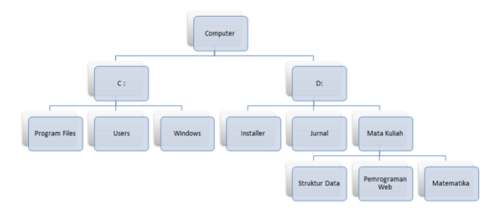

Beberapa istilah pada Tree yang harus diketahui adalah sebagai berikut : Node, merupakan bagian dari tree yang menyimpan informasi atau juga disebut sebagai key

Edge, yang menghubungkan antara node yang satu dengan yang lain. Hanya ada satu edge yang masuk ke dalam node, dan satu atau lebih edge yang keluar dari suatu node

Root, node yang terletak di paling atas, tidak ada edge yang masuk ke dalam node root ini, tapi root mempunyai satu atau lebih dari satu edge yang keluar.

path, merupakan urutan node dari root sampai tujuan, misalkan computer --> D: --> Mata Kuliah --> Struktur Data

children, merupakan node-node yang memiliki edge yang masuk dari node yang sama. Misalkan program files, users, dan windows merupakan children, krn memiliki edge masuk yang sama-sama berasal dari node C:

Parent, node yang memiliki edge yang keluar dari node tersebut, misalkan node C: adalah parent dari program files, users, dan windows

Siblings, adalah node-node yang berasal dari parent yang sama subtree, kumpulan dari node dan edge yang terdiri dari parent dan semua node setelah parent

leaf node, node yang tidak memiliki edge yang keluar, node yang tidak memiliki children

level, tingkatan dari node. Root merupakan level ke-0, semakin kebawah maka level dari node tersebut semakin besar, misalkan struktur data berada di level ke-3

height, merupakan tinggi tree, nilai dari height ini adalah level maksimum dari tree

Binary Tree

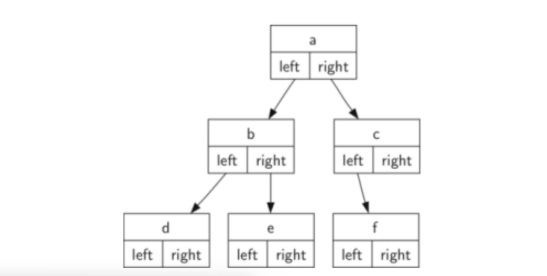